# PS5-DLJ949

Dylan Johnson

2023-02-14

```r
library(tidyverse)
```

# 1 Load and check data (5pt)

You first task is to do a very simple data check:

1. (1pt) For solving the problems, and answering the questions, create a new rmarkdown document with an appropriate title. See [**https://faculty.washington.edu/otoomet/info201-book/r-markdown.html#r-markdown-rstudio-creating**](https://faculty.washington.edu/otoomet/info201-book/r-markdown.html#r-markdown-rstudio-creating).
2. (2pt) Load data. How many rows/columns do we have?

```r
population_data <- read.delim("gapminder.csv")
nrow(population_data)
```

```
## [1] 13055
```

```r
ncol(population_data)
```

```
## [1] 25
```

3. (2pt) Print a small sample of data. Does it look OK?

```r
sample_n(population_data, 2)
```

```
##   iso3     name iso2   region                      sub.region
## 1  HND Honduras   HN Americas Latin America and the Caribbean
## 2  HUN  Hungary   HU   Europe                  Eastern Europe
##   intermediate.region time totalPopulation fertilityRate lifeExpectancy
## 1     Central America 2011         8480671          2.86       73.56900
## 2                     1969        10298723          2.04       69.31463
##   childMortality youthFemaleLiteracy youthMaleLiteracy adultLiteracy   GDP_PC
## 1           22.4            96.92601          94.93154       85.1233 1939.339
## 2           39.8                  NA                NA            NA       NA
##   accessElectricity agriculturalLand agricultureTractors cerealProduction
## 1           82.1953            32900                  NA           635620
## 2                NA            68880               66606          9711470
##   fertilizerHa       co2 greenhouseGases  co2_PC pm2.5_35 battleDeaths
## 1     104.0706  8789.799        20084.14 1.03645  9.55272           NA
## 2     134.3423 62419.674              NA 6.06091       NA           NA
```

The data printed a little strangely, but that is likely due to how many columns there were.

# 2 Descriptive statistics (15pt)

1. (3pt) How many countries are there in the dataset? Analyze all three: *iso3*, *iso2* and *name*.

```r
population_data %>%
  group_by(name) %>%
  filter(!is.na(name)) %>%
  summarise(n = n_distinct(name)) %>%
  arrange(desc(n))
```

```
## # A tibble: 250 × 2
##    name                      n
##    <chr>                 <int>
##  1 ""                        1
##  2 "Afghanistan"             1
##  3 "Albania"                 1
##  4 "Algeria"                 1
##  5 "American Samoa"          1
##  6 "Andorra"                 1
##  7 "Angola"                  1
##  8 "Anguilla"                1
##  9 "Antarctica"              1
## 10 "Antigua and Barbuda"     1
## # … with 240 more rows
```

There are 250 unique country names.

```r
population_data %>%
  group_by(iso2) %>%
  filter(!is.na(name)) %>%
  summarise(n = n_distinct(name)) %>%
  arrange(desc(n))
```

```
## # A tibble: 249 × 2
##    iso2      n
##    <chr> <int>
##  1 ""        2
##  2 "AD"      1
##  3 "AE"      1
##  4 "AF"      1
##  5 "AG"      1
##  6 "AI"      1
##  7 "AL"      1
##  8 "AM"      1
##  9 "AO"      1
## 10 "AQ"      1
## # … with 239 more rows
```

There are 249 unique country iso2 codes, with two countries having an iso-2 code of blank.

```r
population_data %>%
  group_by(iso3) %>%
  filter(!is.na(name)) %>%
  summarise(n = n_distinct(name)) %>%
  arrange(desc(n))
```

```
## # A tibble: 253 × 2
##    iso3      n
##    <chr> <int>
##  1 ABW       1
##  2 AFG       1
##  3 AGO       1
##  4 AIA       1
##  5 ALA       1
##  6 ALB       1
##  7 AND       1
##  8 ARE       1
##  9 ARG       1
## 10 ARM       1
## # … with 243 more rows
```

There are 253 unique iso3 codes.

2. If you did this correctly, you saw that there are more iso-2 codes than names, and there are even more *iso3*-codes. What is going on? Can you find it out?
   1. (5pt) Find how many names are there for each iso-2 code. Are there any iso-2 codes that correspond to more than one name? What are these countries?

   ```r
   population_data %>%
     group_by(name) %>%
     filter(iso2=="" & !is.na(name) & name!="") %>%
     summarise(n = n_distinct(name))
   ```

   ```
   ## # A tibble: 1 × 2
   ##   name        n
   ##   <chr>   <int>
   ## 1 Namibia     1
   ```

There are two iso-2 codes that are blank. One is from Namibia, and the other is from an undisclosed country.

```
(b) (5pt) Now repeat the same for name and iso3-code. Are there country names that have more than one iso3-code? What are these countries? Hint: two of these entitites are *CHANISL* and *NLD CURACAO*.
```

```r
population_data %>%
  filter(!is.na(iso3) & name=="") %>%
  group_by(name) %>%
  distinct(iso3)
```

```
## # A tibble: 4 × 2
## # Groups:   name [1]
##   name  iso3
##   <chr> <chr>
## 1 ""    CHANISL
## 2 ""    GBM
## 3 ""    KOS
## 4 ""    NLD_CURACAO
```

3. (2pt) What is the minimum and maximum year in these data?

```r
min(population_data$time, na.rm = TRUE)
```

```
## [1] 1960
```

```r
max(population_data$time, na.rm = TRUE)
```

```
## [1] 2019
```

# 3 CO2 emissions (30pt)

Next, let’s analyze CO2 emissions.

1. (2pt) How many missing co2 emissions are there for each year? Analyze both missing *CO2* and *co2_PC*. Which years have most missing data?

```r
population_data %>%
  group_by(time) %>%
  filter(is.na(co2), is.na(co2_PC)) %>%
  summarise(num_co2 = length(is.na(co2)),
  num_co2_pc = length(is.na(co2_PC))) %>%
  arrange(rank(desc(num_co2)))
```

```
## # A tibble: 61 × 3
##     time num_co2 num_co2_pc
##    <int>   <int>      <int>
##  1  2017     217        217
##  2  2018     217        217
##  3  2019     217        217
##  4  1960      60         60
##  5  1961      60         60
##  6  1962      58         58
##  7  1963      57         57
##  8  1964      51         51
##  9  1965      51         51
## 10  1966      51         51
## # … with 51 more rows
```

2. (5pt) Make a plot of total CO2 emissions over time for the U.S, China, and India. Add a few more countries of your choice. Explain what do you see.

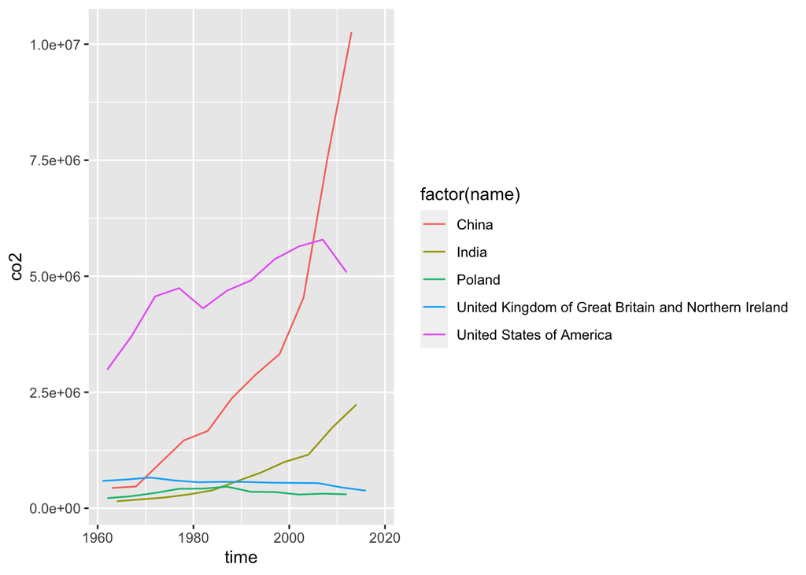

```r
population_data %>%
  filter(name == c("United States of America", "China", "India", "Poland", "United Kingdom of Great Britain and Northern Ireland")) %>%
  ggplot(aes(time, co2, col=factor(name))) +
  geom_line() +
  scale_x_continuous(limits = c(min(population_data$time), max(population_data$time))) +
  scale_y_continuous(limits = c(min(population_data$co2), max(population_data$co2)))
```

We see that the United States during the duration of the Cold War was dominant in its CO2 emissions, but rapidly has been overtaken by the industrializing and new energy production center of the world, China. China has skyrocketed in its harmful CO2 emissions since its turn to communism, but India has also been rapidly increasing its CO2 emissions since the turn of the 21st century. Poland and the UK, however, have stayed relatively low for their entire duration of graphing Co2 emissions.

3. (5pt) Now let’s analyze the CO2 emissions per capita (*co2_PC*). Make a similar plot of thesame countries. What does this figure suggest?

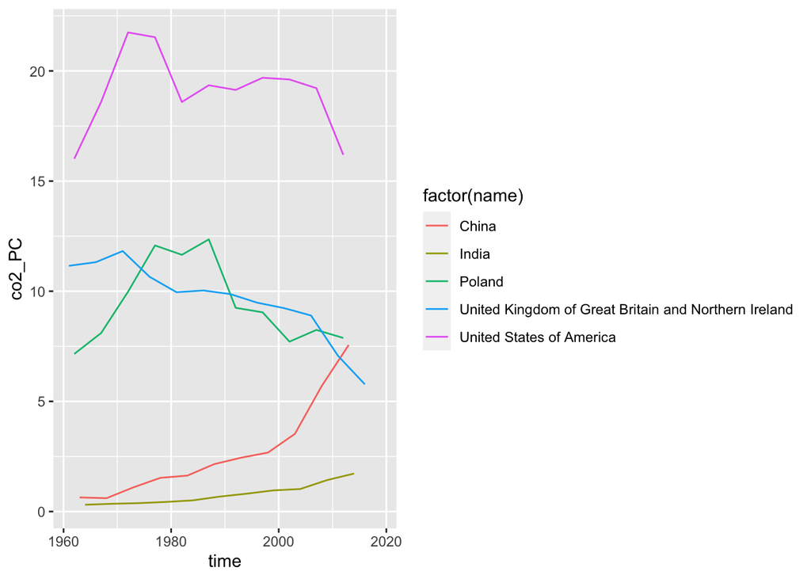

```r
population_data %>%
  filter(name == c("United States of America", "China", "India", "Poland", "United Kingdom of Great Britain and Northern Ireland")) %>%
  ggplot(aes(time, co2_PC, col=factor(name))) +
  geom_line() +
  scale_x_continuous(limits = c(min(population_data$time), max(population_data$time))) +
  scale_y_continuous(limits = c(min(population_data$co2_PC), max(population_data$co2_PC)))
```

4. (6pt) Compute average CO2 emissions per capita across the continents (assume *region* is the same as continent). Comment what do you see.  
   Note: just compute averages over countries and ignore the fact that countries are of different size.  
   Hint: Americas 2016 should be 4.80.

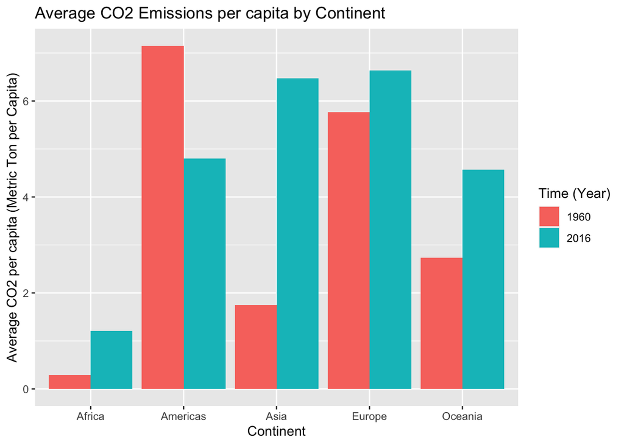

```r
population_data %>%
  select(region, co2_PC, time) %>%
  filter(!is.na(region), !is.na(co2_PC), !region=="", time %in% c("1960", "2016")) %>%
  group_by(region, time) %>%
  summarise(avg_col2_PC = mean(co2_PC, na.rm = TRUE)) %>%
  ggplot(aes(region, avg_col2_PC, fill=factor(time))) +
  geom_col(position="dodge") +
  labs(title = "Average CO2 Emissions per capita by Continent",
       x="Continent",
       y="Average CO2 per capita (Metric Ton per Capita)",
       fill="Time (Year)")
```

5. (7pt) Make a barplot where you show the previous results–average CO2 emissions per capita across continents in 1960 and 2016.  
   Hint: it should look something along these lines(**Please refer to the spec for the graph**)
6. Which countries are the three largest, and three smallest CO2 emitters (in terms of CO2 per capita) in 2019 for each continent? (Assume *region* is continent).

We are missing data for 2019 for most countries, but for 2016 the three largest CO2 emitters per capita continents would be Europe, Asia, and the Americas in that order. The three smallest CO2 emitters (least to greatest) would be Africa, Oceania, and then the Americas. This data, however, filtered out the nameless continent with the large CO2 emissions, so had that counted, the top three would be the nameless contintent, Europe, and Asia and the three smallest would be Africa, Oceania, and the Americas in 2016.

# 4 GDP per capita (50pt)

Let’s look at GDP per capita (*GDP_PC*)

1. (8pt) Make a scatterplot of GDP per capita versus life expectancy by country, using data for 1960. Make the point size dependent on the country size, and color those according to the continent. Feel free to adjust the plot in other ways to make it better.  
   Comment what do you see there.

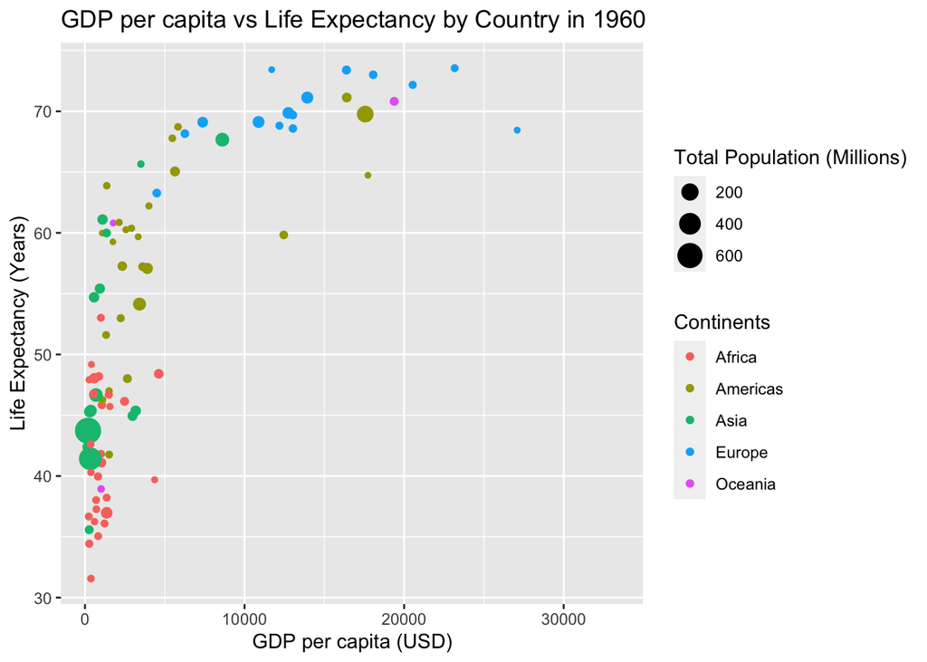

```r
gdp_v_le_1960 <- population_data %>%
  select(name, region, GDP_PC, lifeExpectancy, time, totalPopulation) %>%
  filter(!is.na(name), !is.na(GDP_PC), !is.na(totalPopulation), !name=="",
         time %in% c("1960")) %>%
  group_by(name, time)
  ggplot(gdp_v_le_1960, aes(GDP_PC, lifeExpectancy, col=factor(region))) +
  geom_point(aes(size = totalPopulation/1000000)) +
  labs(title = "GDP per capita vs Life Expectancy by Country in 1960",
       x="GDP per capita (USD)",
       y="Life Expectancy (Years)",
       col = "Continents",
       size = "Total Population (Millions)")
```

2. (4pt) Make a similar plot, but this time use 2019 data only.

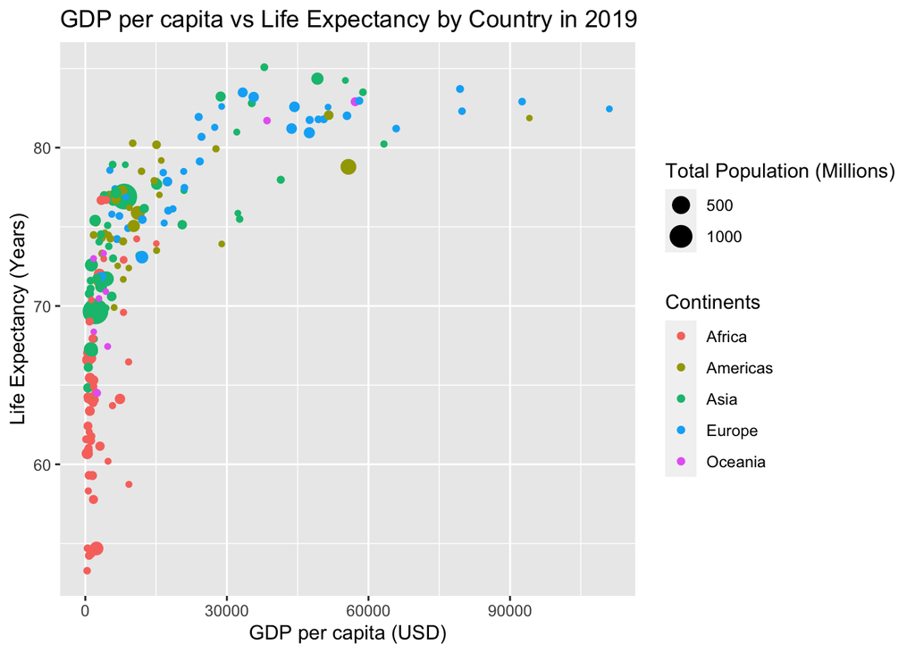

```r
gdp_v_le_2019 <- population_data %>%
  select(name, region, GDP_PC, lifeExpectancy, time, totalPopulation) %>%
  filter(!is.na(name), !is.na(GDP_PC), !is.na(totalPopulation), !name=="",
         time %in% c("2019")) %>%
  group_by(name, time)
  ggplot(gdp_v_le_2019, aes(GDP_PC, lifeExpectancy, col=factor(region))) +
  geom_point(aes(size = totalPopulation/1000000)) +
  labs(title = "GDP per capita vs Life Expectancy by Country in 2019",
       x="GDP per capita (USD)",
       y="Life Expectancy (Years)",
       col = "Continents",
       size = "Total Population (Millions)")
```

3. (6pt) Compare these two plots and comment what do you see. How has world developed through the last 60 years?